# Optimization or design

Daniel Kaplan

There is a calculus problem that has been part of the standard curriculum since Newton’s first work. It appears in Section III of the very first calculus textbook, published in 1696. (English: “Use of the calculus of differences to find the biggest and smallest values, or the reduction of questions *De maximis & minimis.*” )

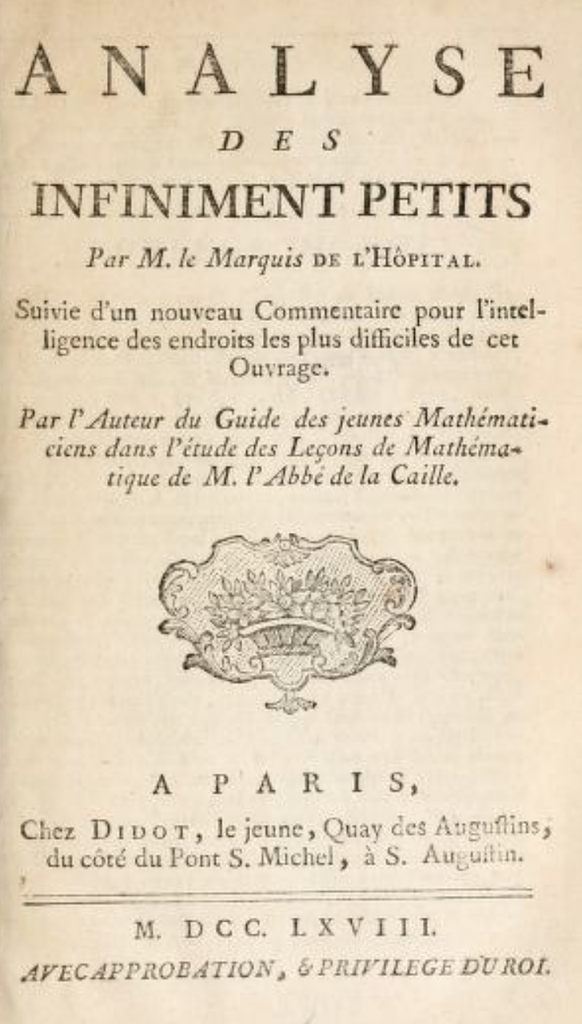

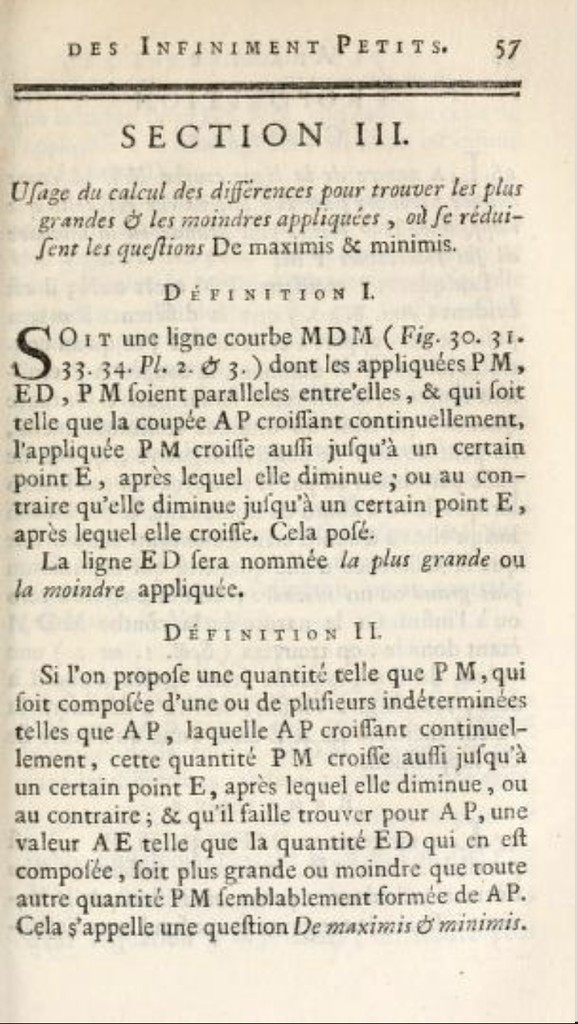

The calculus perspective on *optimization* involves functions whose output is a scalar quantity: a single number. The problem of maximization is to find the input(s) to the function that produce the largest possible output from the function and similarly for minimization: that is, to find the argmax or argmin.

An analogous problem, suited for an elementary-school pupil, is to take a deck of cards, each with a number written on it, and find the card that has the largest number on it. In calculus, we substitute for the discrete domain of the deck of individual cards the continuous domain of the number line (or higher dimensional vector space).

With such a long textbook history, there is a large variety of textbook problems written to illustrate the application of optimization to “real-world” situations. For instance, a famous problem is to find the shape of a tin can (mathematically, a cylinder) that contains a given volume using the least amount of metal (mathematically, the smallest surface area).

It’s important to distinguish between the two distantly related problems of *optimization* and of *design*. Optimization is about finding the single best scalar output of a function. Design is about finding a configuration that suits the needs of a situation. Generally, design involves evaluating trade-offs among multiple objectives. In optimization, there is only a single objective.

Optimization is a far easier problem than design, but design is a far more widely applicable process. Regrettably, generations of students, having been given only the optimization hammer as a tool have been induced to treat design as a nail. The simple concept of “best” applies well to comparing scalar outputs of a function, but when the output is a vector or another function, one can only meaningfully speak of “best for a specific purpose.”

There are several strategies for transforming design problems into optimization problems, but inevitably something is lost in the process. One process is to consider only one dimension of the output. For example, in selecting the “best” electric car, you might reasonably look at the car’s range. But other criteria are important too, for instance the speed with which the batteries can be recharged or the cost of the vehicle. Throughout your professional life, you will likely encounter situations where the criteria for making a design decision have been reduced unnecessarily to low dimension. For instance, in the history of bomber design the criteria “faster, higher, farther” have been emphasized (example: B-1 bomber). Taking into consideration other criteria can considerably change the design, as with “stealth” (the B-2 bomber) or suitability to mission (the A-10 for close air support).

There are some situations, however, where there is a strong logical or economic basis for converting a vector/function output into a scalar. This day’s lesson is about two of those methods, one related particularly to finance and the other to outcomes that are uncertain. (Later on, we’ll examine mathematical techniques for dealing with genuine design-related problems.)